# Pitstop Data Cleaning

Hudson Double

2025-12-03

# 1 Refined Cleaning Methods

## 1.1 Pitstop Data Cleaning and Visualization

While I intend for this project to far eclipse the scope of what is shown here long-term, the pitstop analysis portion aims to assess the operational efficiency of different Formula One teams from 2023-present. Essentially, the motivating question is: how do pit stop durations vary across Formula One teams from 2023–present, and which teams demonstrate the highest operational efficiency? In a series where even marginal differences have a massive impact, routine differences in pitstop performance can account for massive gains or losses for a team.

## 1.2 Loading Data

Using the OpenF1 API, multiple dataframes are loaded, including session_data, pitstop_data, driver_names, and meeting_data, which are added to the workspace.

## 1.3 Session Isolation

Upon importing data, the session_data dataframe is filtered down to just Race Sessions in order to assess operational efficiency of each team. Furthermore, the !duplicated() function is run to remove duplicates, though it has no impact currently.

```r
race_sessions <- dplyr::filter(session_data, session_name == "Race")
race_sessions <- race_sessions[!duplicated(race_sessions$session_key),] #Just  procoutionary, in the current state, this does nothing
```

## 1.4 Driver Data Cleanup

Cleaning up the driver data into a usable state prior to use

### 1.4.1 Merging RB and Racing Bulls

Two of the teams, RB and Racing Bulls, are merged since they’re used interchangeably in the data and they’re the exact same team.

```r
driver_names <- driver_names %>%
  mutate(team_name = ifelse(team_name == "RB", "Racing Bulls", team_name))
```

### 1.4.2 Fixing Color Codes

The driver_names dataframe has a “#” pasted in front of every value in the team_colour column to make the color codes usable.

```r
driver_names$team_colour <- paste0("#", driver_names$team_colour)

driver_names <- driver_names %>%
  group_by(team_name) %>%
  mutate(team_colour = first(team_colour)) %>%
  ungroup()
```

### 1.4.3 Filtering to Race Drivers Only

Next, the dataframe race_drivers_all is created and filters down to only the drivers who have been in race sessions since 2023 when data tracking began.

```r
race_drivers_all <- dplyr::filter(driver_names, session_key %in% race_sessions$session_key)
```

### 1.4.4 Adding Driver Info

From race_drivers_all, limited_drivers is created, which reduces the dimensions of the dataset by removing meeting_key, broadcast_name, first_name, and last_name to reduce complexity.

```r
limited_drivers <- race_drivers_all %>%
  select(-meeting_key, -broadcast_name, -first_name, -last_name)
```

## 1.5 Pitstop Data Cleaning

In this section I am cleaning the pitstop_data$pit_duration to remove na values, and outliers. ### Filtering Down to Race Pitstops Pitstop_data is filtered down to race sessions using the race_sessions data, and NA values are removed; thus, the pitstop dataframe only tracks race data.

```r
pitstop_data <- pitstop_data %>%
  filter(session_key %in% race_sessions$session_key)
```

### 1.5.1 Joining Driver Information

Then, the data from limited_drivers is joined by the columns session_key and driver_number so that corresponding data will match the information of the driver from the specific session.

```r
pitstop_data <- pitstop_data %>%
  left_join(limited_drivers, by = c("session_key", "driver_number")) %>%
  filter(!is.na(pit_duration))
```

### 1.5.2 Removing Country Codes

Country code is removed from the driver information to make way for the country codes of the circuit.

```r
pitstop_data <- pitstop_data %>%
  select(-country_code)
```

### 1.5.3 Merging race_sessions to pitstop_data

Joining session information from race_sessions in order to track races by location and time over time. Specifically, adding Year and circuit_short_name from race_sessions to pitstop_data.

```r
pitstop_data <- pitstop_data %>%
  left_join(race_sessions %>%
  select(session_key, year, circuit_short_name, country_code), by = "session_key")
```

### 1.5.4 Outlier Determination

Outlier determination and removal posed one of the largest challenges due to opaque data tracking methods. Pit duration is measured from pitlane entry to exit, meaning pitstop times vary by track layout.

- Initially, the $1.5 \times IQR$ method was used to identify outliers, but this approach failed to exclude non-pitstop events such as DNFs, red-flag stoppages, and pre-race stops, which skewed the distribution toward extremely long durations.
- A manual threshold of 150 seconds was implemented instead, providing more accurate analysis of in-race pitstop performance while filtering out problematic data points.
- As a result, there are no longer examples of pitstops eclipsing 1000 seconds or more, which heavily distorted the data prior to their removal.

```r
summary(pitstop_data$pit_duration)
```

```
##    Min. 1st Qu.  Median    Mean 3rd Qu.    Max.
##    12.8    21.8    23.5   100.9    27.8  2485.9
```

```r
pitstop_data <- pitstop_data[pitstop_data$pit_duration <= 150,]
pitstop_duration_Q1 <- quantile(pitstop_data$pit_duration, 0.25, na.rm = TRUE)
pitstop_duration_Q3 <- quantile(pitstop_data$pit_duration, 0.75, na.rm = TRUE)
pitstop_iqr <- pitstop_duration_Q3 - pitstop_duration_Q1 #I could also just do this with pitstop_iqr <- IQR(pitstop_data$pit_duration, na.rm = TRUE)
pitstop_median <- median(pitstop_data$pit_duration, na.rm = TRUE)
summary(pitstop_data$pit_duration)
```

```
##    Min. 1st Qu.  Median    Mean 3rd Qu.    Max.
##   12.80   21.70   23.30   24.38   25.70   93.20
```

```r
# pitstop_data <- pitstop_data %>%
#   filter(pit_duration >= (pitstop_duration_Q1 - 1.5 * pitstop_iqr) &
#          pit_duration <= (pitstop_duration_Q3 + 1.5 * pitstop_iqr))
```

### 1.5.5 Finding Mean Pit Durations by Team

Mean durations were tracked as a dataset called mean_pit_duration which is grouped by team and year, for use in ordering the teams.

```r
mean_pit_duration <- pitstop_data %>%
  group_by(team_name, year) %>%
  summarise(mean_duration = mean(pit_duration, na.rm = TRUE)) %>%
  ungroup()
```

## 1.6 Pitstop Averages

pitstop_averages is created from pitstop_data and it takes the mean of every single driver’s pitstop performance, which was later used for a visualization comparing drivers over the past few years.

```r
pitstop_average <- pitstop_data %>%
  group_by(name_acronym, team_name) %>%
  summarise(Mean = mean(pit_duration, na.rm = TRUE))
pitstop_average <- pitstop_average %>%
  left_join(pitstop_data %>%
              select(team_name, team_colour) %>%
              distinct(),
            by = "team_name")

pitstop_average <- pitstop_average %>%
  group_by(name_acronym) %>%
  mutate(driver_label = if(n() > 1) paste0(name_acronym, " (", row_number(), ")") else name_acronym) %>%
  ungroup()
```

## 1.7 Plotting the Results

Using the Results I have previously gathered, this section will contain several plots created form the aggregated data points

### 1.7.1 Boxplot of All Teams

```r
TeamBoxplot <- ggplot(pitstop_data, aes(
      x = reorder(team_name, pit_duration, median),
      y = pit_duration, fill = team_colour)) +
  geom_boxplot(alpha = 0.6, outlier.shape = NA) +
  geom_jitter(width = 0.2, alpha = 0.3, color = "black") +
  coord_flip() +
  scale_y_continuous(limits = c(quantile(pitstop_data$pit_duration, 0.02, na.rm = TRUE),
    quantile(pitstop_data$pit_duration, 0.97, na.rm = TRUE)),
      oob = scales::oob_keep) + #looked up this command
  labs(title = "Pit Stop Duration by Team", x = "Team", y = "Pit Stop Duration (s)") +
  theme_bw()+
  theme(legend.position = "none")+
  scale_fill_identity()

ggplotly(TeamBoxplot, width = 1200, height = 700) %>%
  layout(autosize = TRUE)
```

[interactive chart not shown]

```r
#ggsave("BoxPlots.png", plot = TeamBoxplot, width = 12, height = 7, dpi = 1000)
```

### 1.7.2 Same Boxplot, Only 2025

```r
TeamBoxplot2025 <- ggplot(pitstop_data %>% filter(year == 2025), aes(x = reorder(team_name, pit_duration, median), y = pit_duration, fill = team_colour)) +
  geom_boxplot(alpha = 0.6, outlier.shape = NA) +
  geom_jitter(width = 0.2, alpha = 0.3, color = "black") +
  coord_flip() +
  scale_y_continuous(limits = c(quantile(pitstop_data$pit_duration, 0.02, na.rm = TRUE),
    quantile(pitstop_data$pit_duration, 0.97, na.rm = TRUE)),
      oob = scales::oob_keep) + #looked up this command
  labs(title = "Pit Stop Duration by Team (2025)", x = "Team", y = "Pit Stop Duration (s)") +
  theme_bw()+
  theme(legend.position = "none")+
  scale_fill_identity()

ggsave("BoxPlots2025.png", plot = TeamBoxplot2025, width = 12, height = 7, dpi = 1000)
```

### 1.7.3 Plotting Avergaes

```r
AveragesGraph <- ggplot(pitstop_average, aes(x = reorder(driver_label, Mean), y = Mean, fill = team_name))+
  geom_col()+
  scale_fill_manual(values = setNames(pitstop_average$team_colour, pitstop_average$team_name))+
  labs(x = "Name Acronyms", y = "Mean (s)", title = "Averages Plot")+
  theme(text = element_text(angle = 45, hjust = 1))

ggplotly(AveragesGraph, width = 1200, height = 700) %>%
  layout(autosize = TRUE)
```

[interactive chart not shown]

### 1.7.4 Mean Deviation

Mean deviation of the sample was calculated and merged to pitstop_data by taking the mean of all pitstop for a session before subtracting the mean from each pitstop_duration.

```r
pitstop_data <- pitstop_data %>%
  group_by(session_key) %>%
  mutate(mean_deviation = pit_duration - mean(pit_duration, na.rm = TRUE)) %>%
  ungroup()
```

### 1.7.5 Mean Deviation by Seconds

```r
mean_deviation_seconds <- ggplot(pitstop_data, aes(x = pit_duration, y = mean_deviation, color = team_name)) +
  geom_point() +
  geom_smooth(method = "lm", se = FALSE) +
  scale_color_manual(values = setNames(pitstop_data$team_colour, pitstop_data$team_name)) +
  coord_cartesian(xlim = c(10, 45), ylim = c(-12, 18)) +
  labs(title = "Mean Deviation VS. Seconds", x = "Seconds", y = "Mean Deviation")

ggplotly(mean_deviation_seconds, width = 1200, height = 700) %>%
  layout(autosize = TRUE)
```

[interactive chart not shown]

```r
#ggsave("Mean_Deviation_Seconds.png", plot = mean_deviation_seconds, width = 12, height = 7, dpi = 1000)
```

### 1.7.6 Mean Deviation by Weekend

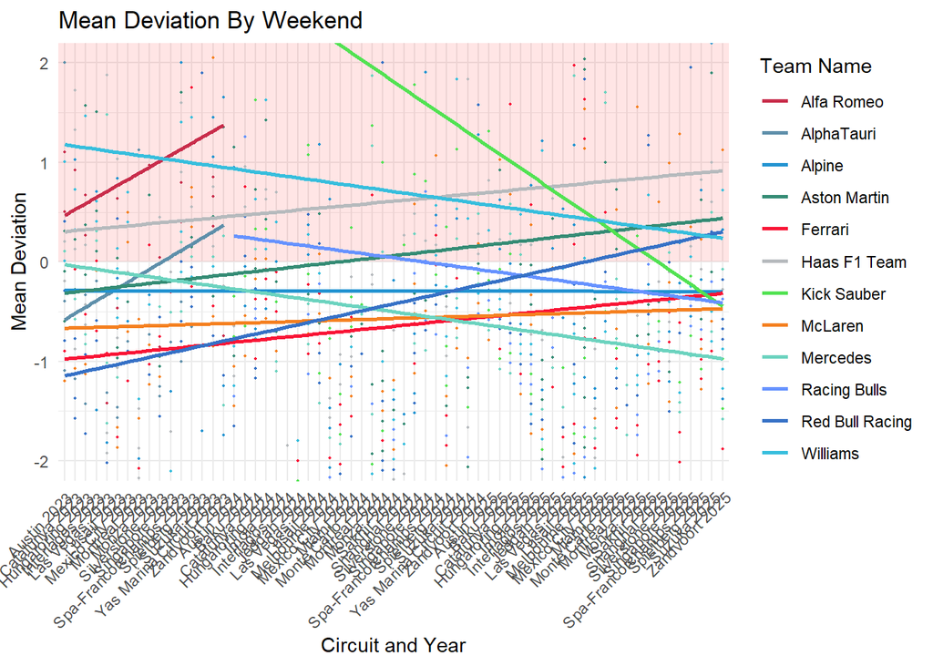

```r
mean_deviation_weekend <- ggplot(pitstop_data, aes(x = interaction(circuit_short_name, year, sep = " "), y = mean_deviation, color = team_name)) +
  annotate("Rect", xmin = -Inf, xmax = Inf, ymin = 0, ymax = Inf, fill = "red", alpha = 0.1)+
  geom_point(size = 0.3) +
  geom_smooth(aes(group = team_name), method = "lm", se = FALSE) +
  coord_cartesian(ylim = c(-2,2)) +
  scale_color_manual(name = "Team Name", values = setNames(pitstop_data$team_colour, pitstop_data$team_name)) +
  labs(title = "Mean Deviation By Weekend", x = "Circuit and Year", y = "Mean Deviation") +
  theme_minimal() +
  scale_y_continuous(breaks = seq(-5, 5, by = 1)) +
  theme(axis.text.x = element_text(angle = 45, hjust = 1))

mean_deviation_weekend
```

```r
ggsave("Mean_Deviation_Weekend.png", plot = mean_deviation_weekend, width = 12, height = 7, dpi = 1000)
```